# Part II - Ford GoBike System Data Analysis

## by Sandra Kamikazi

## Investigation Overview

#### Key Insights for Presentation

My presentation was focused on the organized steps I took to gather the data for my dataset. First, I introduced my dataset and its importance by exhibiting and describing it. Then I started with various cleaning-related tasks, incorporating elements that helped my analysis, such as the days of the week, into the process. Then I started presenting the findings of my research.

I employed various strategies in my research to address particular questions I had for myself, such as what proportions of men and women rent bikes? In order to react to these questions, I used visualizations like donut charts and histograms.

## Dataset Overview

Data collected for the bike-sharing service in the greater San Francisco Bay area includes information on each ride. The Bay Area Bike Share model of the Ford GoBike was first made available in the San Francisco Bay Area in 2013. It was later resurrected as the Ford GoBike. In addition, the system has been known as Bay Wheels since June 2019. The three Bay Wheels pricing tiers are contained in the dataset, so you must be aware of them. Additionally, there are two payment options: paying per trip as a non-user or paying on a monthly or annual subscription basis for Bike Share for All.

## Percentage of users who are male and female

*The gender split is 76.2% men to 23.8% women.*

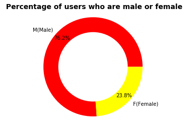

## The number of bike rides rented on the various days of the week

[figure not shown]

## What connection exists between different user categories and the workweek?

Assessing the days of the week that bike service users and subscribers use the service the most. Interestingly, subscribers are most active on Monday, Tuesday, and Wednesday, whereas customers are most active on Monday and Sunday.

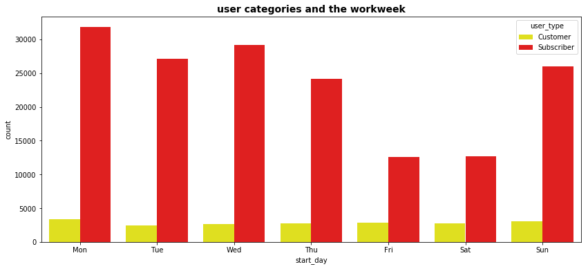

## Average journey length for various users on different days of the week

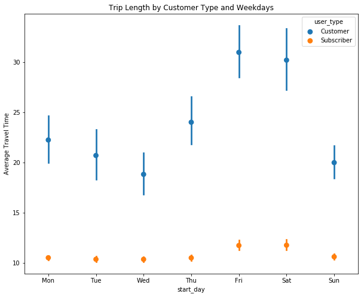